# Supervised Learning - Foundations: ReCell

### Outlier Treatment

- Outlier treatment will not be applied to main_camera_mp, selfie_camera_mp, int_memory, ram, and battery since the data for these columns is discreet, and the high values in those columns are valid values.
- Weight contains continous data. Going to convert to log and see if the distribution changes significantly.
- Both new_price and used_price have very skewed distributions, will apply a log transformation to each to see if that makes the distribution more normal.

```python
# Transforming weight to see if converting to log makes a significant difference in distribution

df_temp = df_processed.copy()
df_temp['weight_log'] = np.log(df_processed['weight'])
```

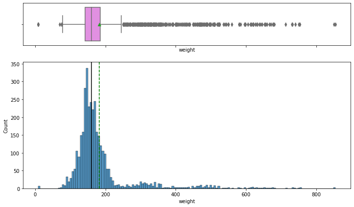

```python
# Distribution of weight
histogram_boxplot(df_temp, 'weight')
```

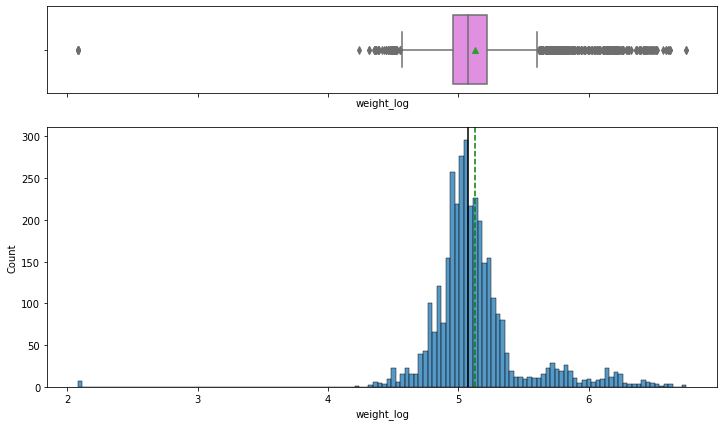

```python
# Distribution of weight_log
histogram_boxplot(df_temp, 'weight_log')
```

### After applying a log transformation to weight, there is very little change in the distribution (it is very similar to the non log distribution. Therefore, no outlier treatment will be applied to weight when building the linear regression model.

```python
# Outlier Treatment
# Both new_price and used_price have very skewed distributions, will apply a log transformation to each to see if that makes the distribution more normal

log_cols = ['new_price', 'used_price']

# applying log transform and creating two new columns to dataframe with transformed values
for col in log_cols:
    df_processed[col + '_log'] = np.log(df_processed[col] + 1)


# dropping original columns
df_processed.drop(log_cols, axis = 1, inplace = True)
df_processed.head()
```

|  | brand_name | os | screen_size | 4g | 5g | main_camera_mp | selfie_camera_mp | int_memory | ram | battery | weight | days_used | age | new_price_log | used_price_log |
| --- | --- | --- | --- | --- | --- | --- | --- | --- | --- | --- | --- | --- | --- | --- | --- |
| 0 | Honor | Android | 14.50 | yes | no | 13.0 | 5.0 | 64.0 | 3.0 | 3020.0 | 146.0 | 127 | 2 | 4.724019 | 4.320949 |
| 1 | Honor | Android | 17.30 | yes | yes | 13.0 | 16.0 | 128.0 | 8.0 | 4300.0 | 213.0 | 325 | 2 | 5.523020 | 5.167810 |
| 2 | Honor | Android | 16.69 | yes | yes | 13.0 | 8.0 | 128.0 | 8.0 | 4200.0 | 213.0 | 162 | 2 | 5.887409 | 5.117095 |
| 3 | Honor | Android | 25.50 | yes | yes | 13.0 | 8.0 | 64.0 | 6.0 | 7250.0 | 480.0 | 345 | 2 | 5.634540 | 5.141254 |
| 4 | Honor | Android | 15.32 | yes | no | 13.0 | 8.0 | 64.0 | 3.0 | 5000.0 | 185.0 | 293 | 2 | 4.954911 | 4.402319 |

```python
# Distribution of used_price
histogram_boxplot(df1, 'used_price')
```

[output not shown]

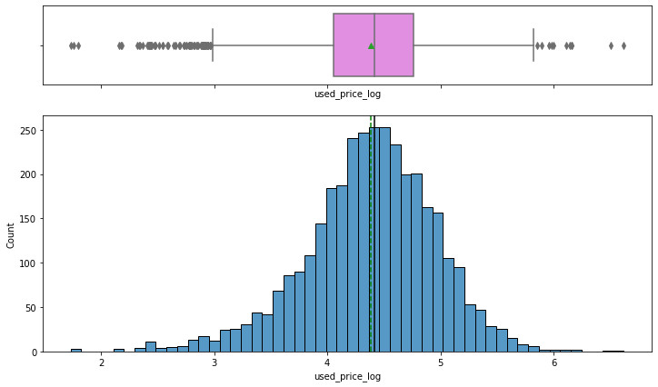

```python
# Distribution of used_price_log
histogram_boxplot(df_processed, 'used_price_log')
```

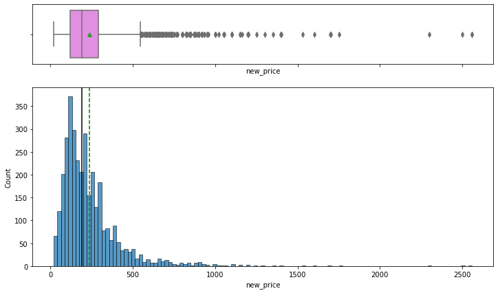

```python
# Distribution of new_price
histogram_boxplot(df1, 'new_price')
```

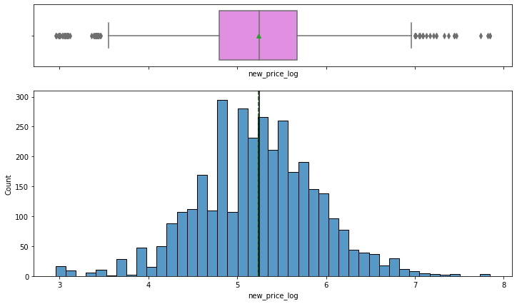

```python
# Distribution of new_price_log
histogram_boxplot(df_processed, 'new_price_log')
```

### After applying the log transformation to both used_price and new_price and comparing the non log and log distributions, the log distributions for both used_price_log and new_price_log are closer to a normal distribution than the non log versions. The log transformation (used_price_log and new_price_log) will both be used in the linear regression model.

## EDA (After Data Preprocessing)

- It is a good idea to explore the data once again after manipulating it.

### Univariate Analysis (on imputed or transformed values)

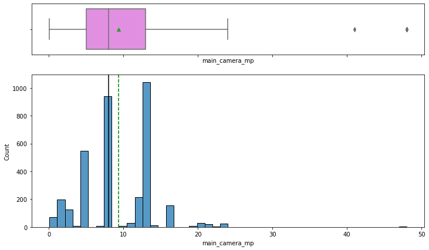

```python
# main_camera_mp
histogram_boxplot(df_processed, 'main_camera_mp')
```

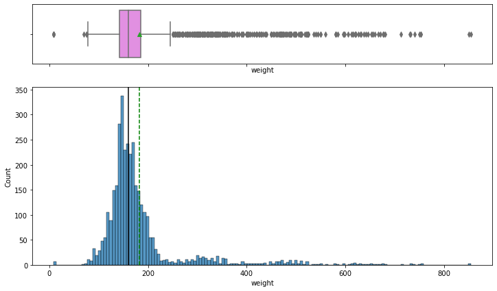

```python
# weight
histogram_boxplot(df_processed, 'weight')
```

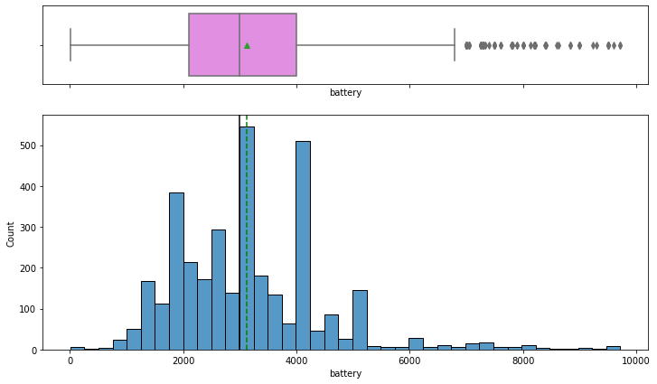

```python
# battery
histogram_boxplot(df_processed, 'battery')
```

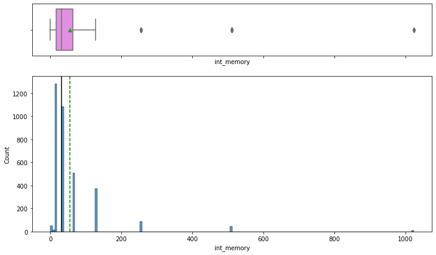

```python
# int_memory
histogram_boxplot(df_processed, 'int_memory')
```

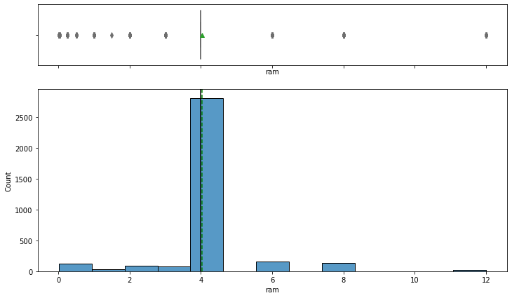

```python
# ram
histogram_boxplot(df_processed, 'ram')
```

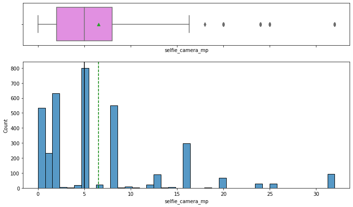

```python
# selife_camera_mp
histogram_boxplot(df_processed, 'selfie_camera_mp')
```

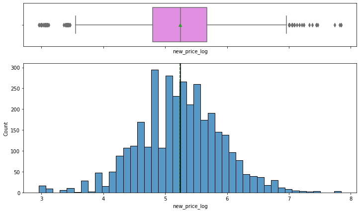

```python
# new_price_log
histogram_boxplot(df_processed, 'new_price_log')
```

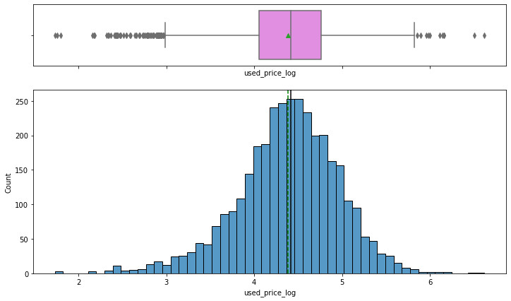

```python
# used_price_log
histogram_boxplot(df_processed, 'used_price_log')
```

### Observations

- Columns that didn't have any transformation applied aren't plotted here, as they are the same as the initial univariate analysis.
- Except for the used_price_log and new_price_log, all the other columns that got values imputed (main_camera_mp, weight, battery, int_memory, ram, selfie_camera_mp) have very similar distributions as before.
- used_price_log nad new_price_log are now closer to normal distributions due to the log transformation applied to each of them.

### Bivariate Analysis (on imputed or transformed values)

```python
# Finding correlations of all attributes with used_price_log sorted in descending order
df_processed[df_processed.columns[:]].corr()['used_price_log'][:].sort_values(ascending = False)
```

```
used_price_log      1.000000
new_price_log       0.834349
screen_size         0.614702
battery             0.611891
selfie_camera_mp    0.610180
main_camera_mp      0.551904
ram                 0.509306
weight              0.384041
int_memory          0.195521
days_used          -0.360167
age                -0.511336
Name: used_price_log, dtype: float64
```

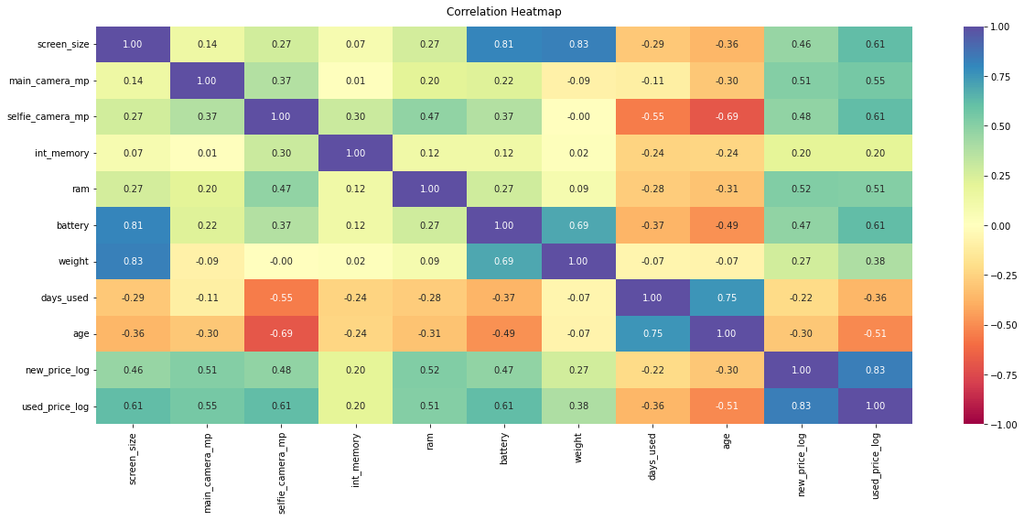

```python
# Specifying numeric columns for a correlation heatmap
numeric_columns = df_processed.select_dtypes(include = np.number).columns.tolist()

# Correlation heatmap
plt.figure(figsize=(20, 8))

# Store heatmap object in a variable to easily access it when you want to include more features (such as title).
# Set the range of values to be displayed on the colormap from -1 to 1, and set the annotation to True to display the correlation values on the heatmap.
heatmap = sns.heatmap(df_processed[numeric_columns].corr(), annot = True, vmin = -1, vmax = 1, fmt = '.2f', cmap = 'Spectral')

# Give a title to the heatmap. Pad defines the distance of the title from the top of the heatmap.
heatmap.set_title('Correlation Heatmap', fontdict={'fontsize':12}, pad=12);
```

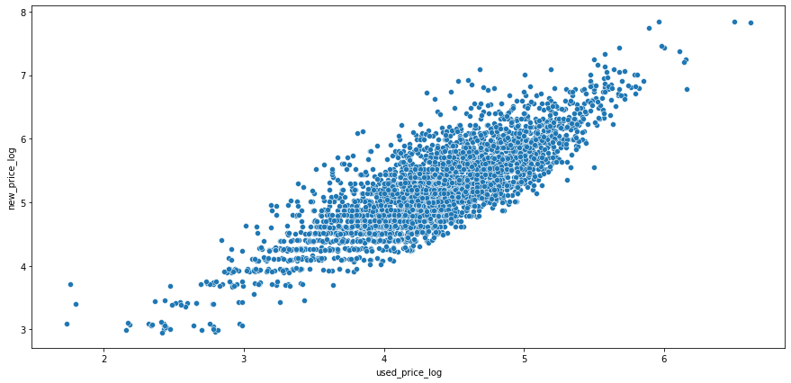

```python
# used_price_log vs new_price_log
plt.figure(figsize=(15,7))
sns.scatterplot(x = 'used_price_log', y = 'new_price_log', data = df_processed)
plt.show()
```

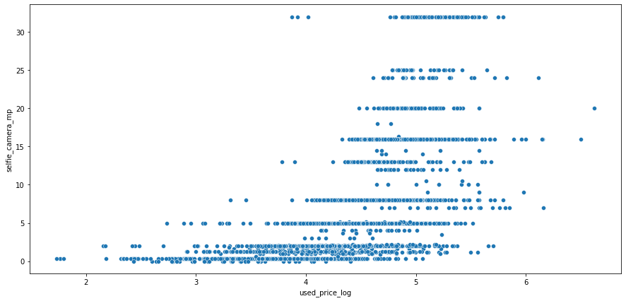

```python
# used_price_log vs selfie_camera_mp
plt.figure(figsize=(15,7))
sns.scatterplot(x = 'used_price_log', y = 'selfie_camera_mp', data = df_processed)
plt.show()
```

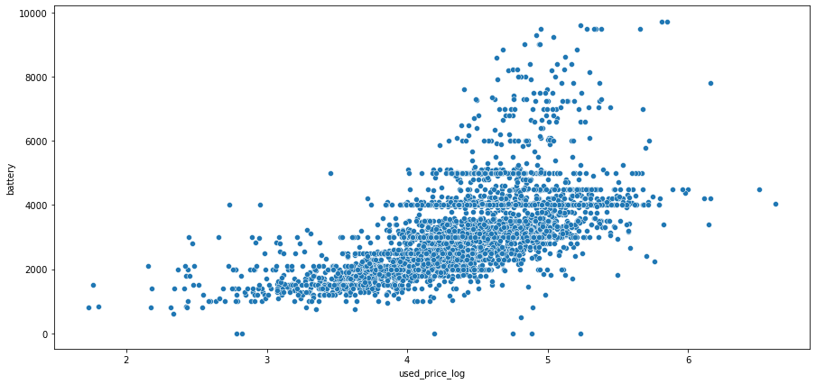

```python
# used_price_log vs battery
plt.figure(figsize=(15,7))
sns.scatterplot(x = 'used_price_log', y = 'battery', data = df_processed)
plt.show()
```

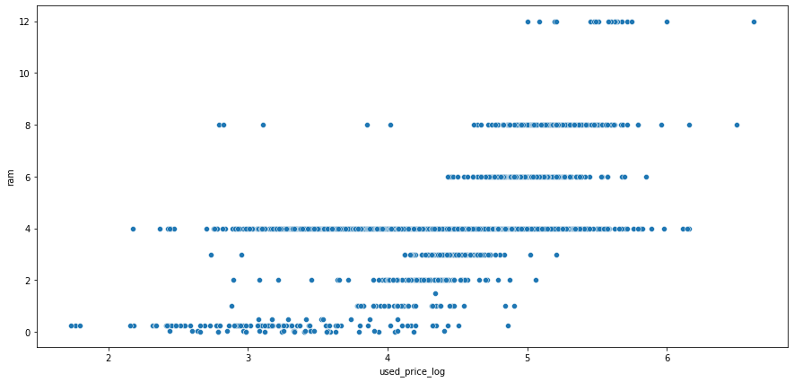

```python
# used_price_log vs ram
plt.figure(figsize=(15,7))
sns.scatterplot(x = 'used_price_log', y = 'ram', data = df_processed)
plt.show()
```

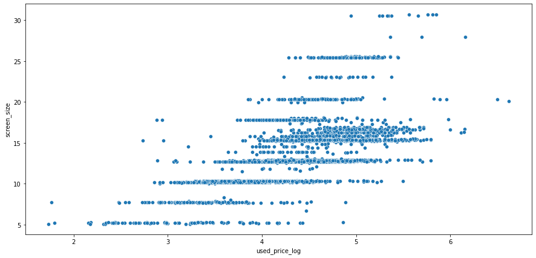

```python
# used_price_log vs screen_size
plt.figure(figsize=(15,7))
sns.scatterplot(x = 'used_price_log', y = 'screen_size', data = df_processed)
plt.show()
```

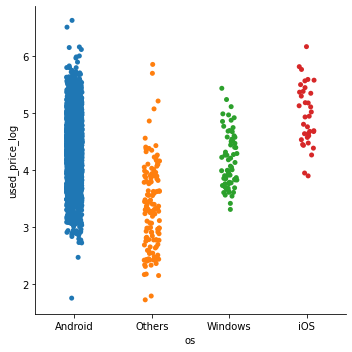

```python
# used_price_log vs os catplot
sns.catplot(x = 'os', y = 'used_price_log' , data = df_processed)
plt.show()
```

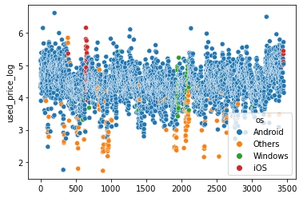

```python
# used_price_log vs os scatter plot
sns.scatterplot(x = df_processed.index, y = 'used_price_log', hue = 'os', data = df_processed)
plt.show()
```

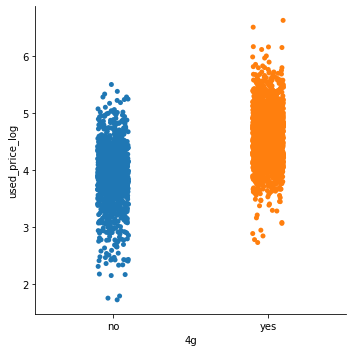

```python
# used_price vs 4G catplot
sns.catplot(x = '4g', y = 'used_price_log' , data = df_processed)
plt.show()
```

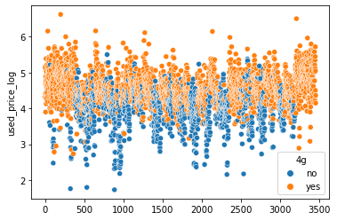

```python
# used_price_log vs 4g scatterplot
sns.scatterplot(x = df_processed.index, y = 'used_price_log', hue = '4g', data = df_processed)
plt.show()
```

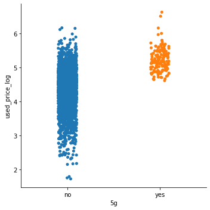

```python
# used_price_log vs 5G catplot
sns.catplot(x = '5g', y = 'used_price_log' , data = df_processed)
plt.show()
```

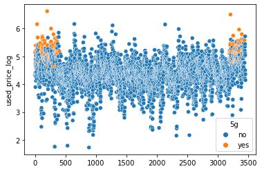

```python
# used_price_log vs 5g scatter plot
sns.scatterplot(x = df_processed.index, y = 'used_price_log', hue = '5g', data = df_processed)
plt.show()
```

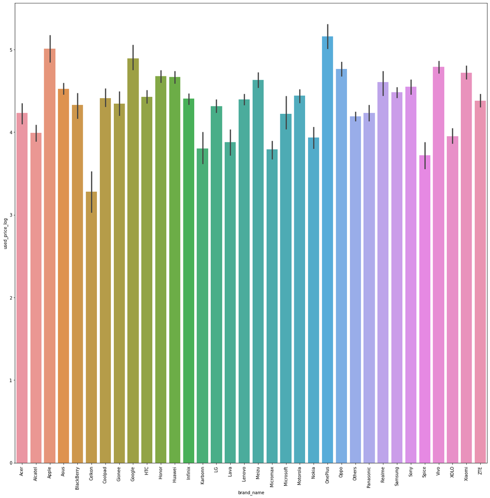

```python
# used_price_log vs. brand_name barplot
plt.figure(figsize = (20,20))
sns.barplot(data = df_processed, x = 'brand_name', y = 'used_price_log')
plt.xticks(rotation = 90)
plt.show()
```

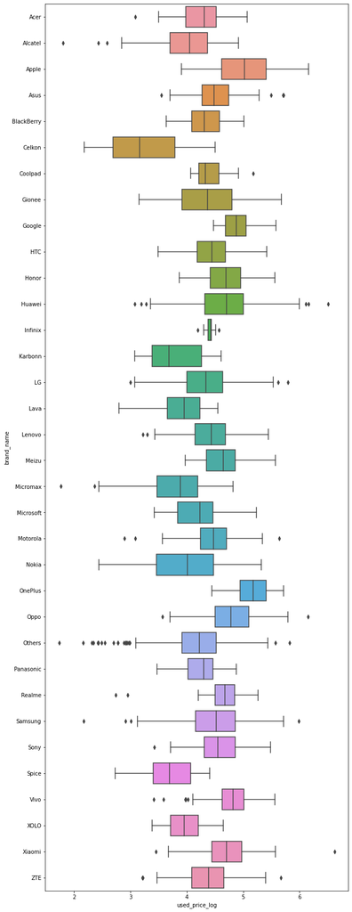

```python
# used_price_log vs. brand boxplot
plt.figure(figsize = (10,30))
sns.boxplot(data = df_processed, y = 'brand_name', x = 'used_price_log')
plt.show()
```

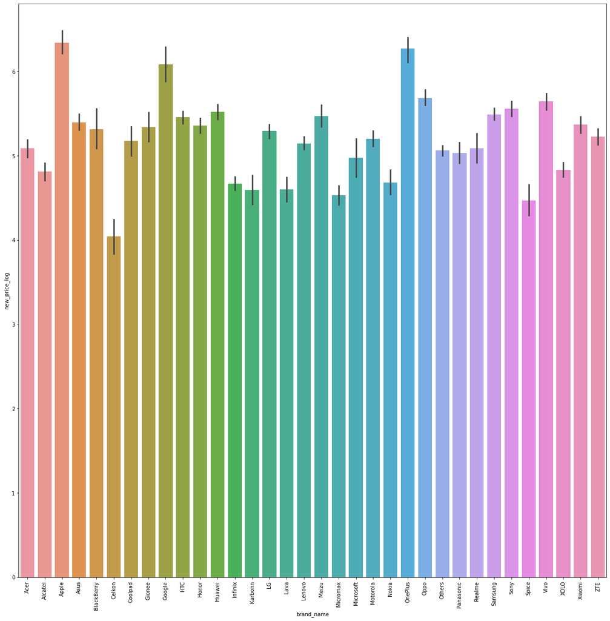

```python
# new_price_log vs. brand_name barplot
plt.figure(figsize = (20,20))
sns.barplot(data = df_processed, x = 'brand_name', y = 'new_price_log')
plt.xticks(rotation = 90)
plt.show()
```

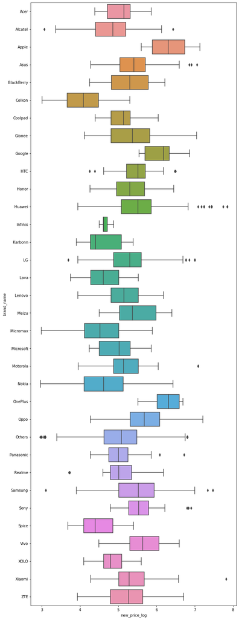

```python
# new_price_log vs. brand boxplot
plt.figure(figsize = (10,30))
sns.boxplot(data = df_processed, y = 'brand_name', x = 'new_price_log')
plt.show()
```

## Building a Linear Regression model

```python
# Importing warnings to ignore a Future Warning associated with get_dummies
import warnings
warnings.simplefilter(action = 'ignore', category = FutureWarning)

# Defining used_price_log as dependent variable
X = df_processed.drop(['used_price_log'], axis = 1)
y = df_processed['used_price_log']

# Adding the intercept to the data
X = sm.add_constant(X)

# Creating dummy variables for categorical features
X = pd.get_dummies(X, columns = X.select_dtypes(include=['category']).columns.tolist(), drop_first=True)

# Ensure all variables are of float type
X = X.astype(float)

X.head()
```

|  | const | screen_size | main_camera_mp | selfie_camera_mp | int_memory | ram | battery | weight | days_used | age | ... | brand_name_Spice | brand_name_Vivo | brand_name_XOLO | brand_name_Xiaomi | brand_name_ZTE | os_Others | os_Windows | os_iOS | 4g_yes | 5g_yes |
| --- | --- | --- | --- | --- | --- | --- | --- | --- | --- | --- | --- | --- | --- | --- | --- | --- | --- | --- | --- | --- | --- |
| 0 | 1.0 | 14.50 | 13.0 | 5.0 | 64.0 | 3.0 | 3020.0 | 146.0 | 127.0 | 2.0 | ... | 0.0 | 0.0 | 0.0 | 0.0 | 0.0 | 0.0 | 0.0 | 0.0 | 1.0 | 0.0 |
| 1 | 1.0 | 17.30 | 13.0 | 16.0 | 128.0 | 8.0 | 4300.0 | 213.0 | 325.0 | 2.0 | ... | 0.0 | 0.0 | 0.0 | 0.0 | 0.0 | 0.0 | 0.0 | 0.0 | 1.0 | 1.0 |
| 2 | 1.0 | 16.69 | 13.0 | 8.0 | 128.0 | 8.0 | 4200.0 | 213.0 | 162.0 | 2.0 | ... | 0.0 | 0.0 | 0.0 | 0.0 | 0.0 | 0.0 | 0.0 | 0.0 | 1.0 | 1.0 |
| 3 | 1.0 | 25.50 | 13.0 | 8.0 | 64.0 | 6.0 | 7250.0 | 480.0 | 345.0 | 2.0 | ... | 0.0 | 0.0 | 0.0 | 0.0 | 0.0 | 0.0 | 0.0 | 0.0 | 1.0 | 1.0 |
| 4 | 1.0 | 15.32 | 13.0 | 8.0 | 64.0 | 3.0 | 5000.0 | 185.0 | 293.0 | 2.0 | ... | 0.0 | 0.0 | 0.0 | 0.0 | 0.0 | 0.0 | 0.0 | 0.0 | 1.0 | 0.0 |

5 rows × 49 columns

```python
# Splitting the data in 70:30 ratio with 70% for training the model and 30% for testing the model

x_train, x_test, y_train, y_test = train_test_split(X, y, test_size = 0.3, random_state = 1)

print("Number of rows in the train data is:", x_train.shape[0])
print("Number of rows in the test data is:", x_test.shape[0])
```

```
Number of rows in the train data is: 2417
Number of rows in the test data is: 1037
```

```python
# Fitting a linear regression model using Ordinary Least Squares (OLS)
olsmodel = sm.OLS(y_train, x_train).fit()
print(olsmodel.summary())
```

```
                            OLS Regression Results
==============================================================================
Dep. Variable:         used_price_log   R-squared:                       0.845
Model:                            OLS   Adj. R-squared:                  0.842
Method:                 Least Squares   F-statistic:                     269.9
Date:                Fri, 04 Feb 2022   Prob (F-statistic):               0.00
Time:                        21:27:51   Log-Likelihood:                 172.01
No. Observations:                2417   AIC:                            -246.0
Df Residuals:                    2368   BIC:                             37.70
Df Model:                          48
Covariance Type:            nonrobust
=========================================================================================
                            coef    std err          t      P>|t|      [0.025      0.975]
-----------------------------------------------------------------------------------------
const                     1.4022      0.071     19.722      0.000       1.263       1.542
screen_size               0.0245      0.003      7.414      0.000       0.018       0.031
main_camera_mp            0.0199      0.001     13.822      0.000       0.017       0.023
selfie_camera_mp          0.0135      0.001     12.243      0.000       0.011       0.016
int_memory                0.0001   6.83e-05      1.797      0.072   -1.12e-05       0.000
ram                       0.0230      0.005      4.645      0.000       0.013       0.033
battery               -1.353e-05   6.98e-06     -1.938      0.053   -2.72e-05    1.59e-07
weight                    0.0009      0.000      7.288      0.000       0.001       0.001
days_used              3.537e-05   3.03e-05      1.168      0.243    -2.4e-05    9.48e-05
age                      -0.0240      0.004     -5.368      0.000      -0.033      -0.015
new_price_log             0.4248      0.012     35.108      0.000       0.401       0.448
brand_name_Alcatel        0.0147      0.047      0.316      0.752      -0.077       0.106
brand_name_Apple         -0.0117      0.144     -0.081      0.935      -0.294       0.271
brand_name_Asus           0.0197      0.047      0.419      0.675      -0.072       0.112
brand_name_BlackBerry    -0.0335      0.069     -0.486      0.627      -0.168       0.101
brand_name_Celkon        -0.0389      0.065     -0.599      0.549      -0.166       0.088
brand_name_Coolpad        0.0380      0.071      0.532      0.595      -0.102       0.178
brand_name_Gionee         0.0448      0.057      0.791      0.429      -0.066       0.156
brand_name_Google        -0.0329      0.083     -0.397      0.692      -0.196       0.130
brand_name_HTC           -0.0107      0.047     -0.227      0.820      -0.103       0.082
brand_name_Honor          0.0228      0.048      0.473      0.636      -0.072       0.117
brand_name_Huawei        -0.0078      0.044     -0.179      0.858      -0.093       0.078
brand_name_Infinix        0.1460      0.091      1.599      0.110      -0.033       0.325
brand_name_Karbonn        0.0951      0.066      1.446      0.148      -0.034       0.224
brand_name_LG            -0.0147      0.044     -0.330      0.741      -0.102       0.072
brand_name_Lava           0.0318      0.061      0.520      0.603      -0.088       0.152
```

[output cut: 19 more lines]

```
os_Windows               -0.0113      0.044     -0.256      0.798      -0.098       0.075
os_iOS                   -0.0521      0.144     -0.363      0.717      -0.334       0.229
4g_yes                    0.0497      0.016      3.186      0.001       0.019       0.080
5g_yes                   -0.0383      0.031     -1.236      0.217      -0.099       0.022
==============================================================================
Omnibus:                      188.318   Durbin-Watson:                   1.904
Prob(Omnibus):                  0.000   Jarque-Bera (JB):              320.211
Skew:                          -0.571   Prob(JB):                     2.93e-70
Kurtosis:                       4.370   Cond. No.                     1.78e+05
==============================================================================

Notes:
[1] Standard Errors assume that the covariance matrix of the errors is correctly specified.
[2] The condition number is large, 1.78e+05. This might indicate that there are
strong multicollinearity or other numerical problems.
```

### Interpreting the Regression Results:

1. **Adjusted. R-squared**: It reflects the fit of the model.
   - Adjusted R-squared values generally range from 0 to 1, where a higher value generally indicates a better fit, assuming certain conditions are met.
   - The value for adj. R-squared is **0.842**, which is good!
1. *const* coefficient: It is the Y-intercept.
   - It means that if all the predictor variable coefficients are zero, then the expected output (i.e., Y) would be equal to the *const* coefficient.
   - The value for *const* coefficient is **1.4022**
1. **Coefficient of a predictor variable**: It represents the change in the output Y due to a change in the predictor variable (everything else held constant).
   - The coefficient of `sceen_size` is **0.0245**.

## Model performance evaluation

- Will use metric functions defined in sklearn for RMSE, MAE, and $R^2$.
- Will define functions to calculate adjusted $R^2$ and MAPE.
  - The mean absolute percentage error (MAPE) measures the accuracy of predictions as a percentage, and can be calculated as the average absolute percent error for each predicted value minus actual values divided by actual values. It works best if there are no extreme values in the data and none of the actual values are 0.
- Will create a function that will print out all the above metrics in one go.

```python
# function to compute adjusted R-squared
def adj_r2_score(predictors, targets, predictions):
    r2 = r2_score(targets, predictions)
    n = predictors.shape[0]
    k = predictors.shape[1]
    return 1 - ((1 - r2) * (n - 1) / (n - k - 1))


# function to compute MAPE
def mape_score(targets, predictions):
    return np.mean(np.abs(targets - predictions) / targets) * 100


# function to compute different metrics to check performance of a regression model
def model_performance_regression(model, predictors, target):
    """
    Function to compute different metrics to check regression model performance

    model: regressor
    predictors: independent variables
    target: dependent variable
    """

    # predicting using the independent variables
    pred = model.predict(predictors)

    r2 = r2_score(target, pred)  # to compute R-squared
    adjr2 = adj_r2_score(predictors, target, pred)  # to compute adjusted R-squared
    rmse = np.sqrt(mean_squared_error(target, pred))  # to compute RMSE
    mae = mean_absolute_error(target, pred)  # to compute MAE
    mape = mape_score(target, pred)  # to compute MAPE

    # creating a dataframe of metrics
    df_perf = pd.DataFrame(
        {
            "RMSE": rmse,
            "MAE": mae,
            "R-squared": r2,
            "Adj. R-squared": adjr2,
            "MAPE": mape,
        },
        index=[0],
    )

    return df_perf
```

```python
# Checking model performance on training set
print('Training Performance\n')
olsmodel_train_perf = model_performance_regression(olsmodel, x_train, y_train)
olsmodel_train_perf
```

```
Training Performance
```

|  | RMSE | MAE | R-squared | Adj. R-squared | MAPE |
| --- | --- | --- | --- | --- | --- |
| 0 | 0.225349 | 0.177475 | 0.845441 | 0.842241 | 4.221795 |

```python
# Checking model performance on test set
print('Test Performance\n')
olsmodel_test_perf = model_performance_regression(olsmodel, x_test, y_test)
olsmodel_test_perf
```

```
Test Performance
```

|  | RMSE | MAE | R-squared | Adj. R-squared | MAPE |
| --- | --- | --- | --- | --- | --- |
| 0 | 0.233151 | 0.180884 | 0.843204 | 0.835419 | 4.359777 |

## Checking Linear Regression Assumptions

- In order to make statistical inferences from a linear regression model, it is important to ensure that the assumptions of linear regression are satisfied.

We will be checking the following Linear Regression assumptions:

1. **No Multicollinearity**
2. **Linearity of variables**
3. **Independence of error terms**
4. **Normality of error terms**
5. **No Heteroscedasticity**

### TEST FOR MULTICOLLINEARITY

- Multicollinearity occurs when predictor variables in a regression model are correlated. This correlation is a problem because predictor variables should be independent. If the correlation between variables is high, it can cause problems when we fit the model and interpret the results. When we have multicollinearity in the linear model, the coefficients that the model suggests are unreliable.
- There are different ways of detecting (or testing) multicollinearity. One such way is by using the Variance Inflation Factor, or VIF.
- **Variance Inflation Factor (VIF)**: Variance inflation factors measure the inflation in the variances of the regression parameter estimates due to collinearities that exist among the predictors. It is a measure of how much the variance of the estimated regression coefficient $\beta_k$ is "inflated" by the existence of correlation among the predictor variables in the model.
  - If VIF is 1, then there is no correlation among the $k$th predictor and the remaining predictor variables, and hence, the variance of $\beta_k$ is not inflated at all.
- **General Rule of thumb**:
  - If VIF is between 1 and 5, then there is low multicollinearity.
  - If VIF is between 5 and 10, we say there is moderate multicollinearity.
  - If VIF is exceeding 10, it shows signs of high multicollinearity.
- NOTE: If there are dummy variables with VIF > 5, they won't be dropped to avoid perfect multicollinearity.

```python
from statsmodels.stats.outliers_influence import variance_inflation_factor

# we will define a function to check VIF
def checking_vif(predictors):
    vif = pd.DataFrame()
    vif["feature"] = predictors.columns

    # calculating VIF for each feature
    vif["VIF"] = [
        variance_inflation_factor(predictors.values, i)
        for i in range(len(predictors.columns))
    ]
    return vif
```

```python
checking_vif(x_train)
```

|  | feature | VIF |
| --- | --- | --- |
| 0 | const | 235.710404 |
| 1 | screen_size | 7.509135 |
| 2 | main_camera_mp | 2.130501 |
| 3 | selfie_camera_mp | 2.801066 |
| 4 | int_memory | 1.362397 |
| 5 | ram | 2.188343 |
| 6 | battery | 3.944892 |
| 7 | weight | 6.173144 |
| 8 | days_used | 2.666324 |
| 9 | age | 4.892870 |
| 10 | new_price_log | 3.113747 |
| 11 | brand_name_Alcatel | 3.405478 |
| 12 | brand_name_Apple | 13.051222 |
| 13 | brand_name_Asus | 3.330404 |
| 14 | brand_name_BlackBerry | 1.631959 |
| 15 | brand_name_Celkon | 1.773565 |
| 16 | brand_name_Coolpad | 1.466496 |
| 17 | brand_name_Gionee | 1.950639 |
| 18 | brand_name_Google | 1.321776 |
| 19 | brand_name_HTC | 3.409657 |
| 20 | brand_name_Honor | 3.345488 |
| 21 | brand_name_Huawei | 5.986170 |
| 22 | brand_name_Infinix | 1.282440 |
| 23 | brand_name_Karbonn | 1.573069 |
| 24 | brand_name_LG | 4.848142 |
| 25 | brand_name_Lava | 1.711154 |
| 26 | brand_name_Lenovo | 4.558680 |
| 27 | brand_name_Meizu | 2.172851 |
| 28 | brand_name_Micromax | 3.363071 |
| 29 | brand_name_Microsoft | 1.871279 |
| 30 | brand_name_Motorola | 3.259677 |
| 31 | brand_name_Nokia | 3.464803 |
| 32 | brand_name_OnePlus | 1.436523 |
| 33 | brand_name_Oppo | 3.971253 |
| 34 | brand_name_Others | 9.710294 |
| 35 | brand_name_Panasonic | 2.105468 |
| 36 | brand_name_Realme | 1.929788 |
| 37 | brand_name_Samsung | 7.539501 |
| 38 | brand_name_Sony | 2.931683 |
| 39 | brand_name_Spice | 1.688544 |
| 40 | brand_name_Vivo | 3.647033 |
| 41 | brand_name_XOLO | 2.148505 |
| 42 | brand_name_Xiaomi | 3.710860 |
| 43 | brand_name_ZTE | 3.795981 |
| 44 | os_Others | 1.838488 |
| 45 | os_Windows | 1.594208 |
| 46 | os_iOS | 11.776014 |
| 47 | 4g_yes | 2.479473 |
| 48 | 5g_yes | 1.830888 |

### Observations

- `screen_size` and `weight`have VIF scores greater than 5 and less than 10, which means they have moderate multicollinearity.
  - These 2 variables are correlated with each other.
  - This makes intuitive sense as the device screen size increases, weight most likley would be increasing.

### Removing Multicollinearity

To remove multicollinearity

1. Drop every column one by one that has a VIF score greater than 5.
2. Look at the adjusted R-squared and RMSE of all these models.
3. Drop the variable that makes the least change in adjusted R-squared.
4. Check the VIF scores again.
5. Continue till you get all VIF scores under 5.

Let's define a function that will help us do this.

```python
# Treating Multicollinearity function
def treating_multicollinearity(predictors, target, high_vif_columns):
    """
    Checking the effect of dropping the columns showing high multicollinearity
    on model performance (adj. R-squared and RMSE)

    predictors: independent variables
    target: dependent variable
    high_vif_columns: columns having high VIF
    """
    # empty lists to store adj. R-squared and RMSE values
    adj_r2 = []
    rmse = []

    # build ols models by dropping one of the high VIF columns at a time
    # store the adjusted R-squared and RMSE in the lists defined previously
    for cols in high_vif_columns:
        # defining the new train set
        train = predictors.loc[:, ~predictors.columns.str.startswith(cols)]

        # create the model
        olsmodel = sm.OLS(target, train).fit()

        # adding adj. R-squared and RMSE to the lists
        adj_r2.append(olsmodel.rsquared_adj)
        rmse.append(np.sqrt(olsmodel.mse_resid))

    # creating a dataframe for the results
    temp = pd.DataFrame(
        {
            "col": high_vif_columns,
            "Adj. R-squared after_dropping col": adj_r2,
            "RMSE after dropping col": rmse,
        }
    ).sort_values(by="Adj. R-squared after_dropping col", ascending=False)
    temp.reset_index(drop=True, inplace=True)

    return temp
```

```python
# Making a list of columns with VIF scores > 5
col_list = ['screen_size', 'weight']

res = treating_multicollinearity(x_train, y_train, col_list)
res
```

|  | col | Adj. R-squared after_dropping col | RMSE after dropping col |
| --- | --- | --- | --- |
| 0 | weight | 0.838839 | 0.230159 |
| 1 | screen_size | 0.838715 | 0.230247 |

- Dropping `screen_size` would have the maximum impact on the predictive power of the model (amongst the variables being considered).
- Dropping `weight` and check the VIF again.

```python
col_to_drop = 'weight'
x_train1 = x_train.loc[:, ~x_train.columns.str.startswith(col_to_drop)]
x_test1 = x_test.loc[:, ~x_test.columns.str.startswith(col_to_drop)]

# Check VIF now
vif = checking_vif(x_train1)
print('VIF after dropping', col_to_drop)
vif
```

```
VIF after dropping weight
```

|  | feature | VIF |
| --- | --- | --- |
| 0 | const | 214.980235 |
| 1 | screen_size | 3.502932 |
| 2 | main_camera_mp | 2.051743 |
| 3 | selfie_camera_mp | 2.777227 |
| 4 | int_memory | 1.362291 |
| 5 | ram | 2.185976 |
| 6 | battery | 3.599936 |
| 7 | days_used | 2.655672 |
| 8 | age | 4.709052 |
| 9 | new_price_log | 3.110102 |
| 10 | brand_name_Alcatel | 3.405432 |
| 11 | brand_name_Apple | 13.046543 |
| 12 | brand_name_Asus | 3.328098 |
| 13 | brand_name_BlackBerry | 1.631906 |
| 14 | brand_name_Celkon | 1.773201 |
| 15 | brand_name_Coolpad | 1.466471 |
| 16 | brand_name_Gionee | 1.950611 |
| 17 | brand_name_Google | 1.321622 |
| 18 | brand_name_HTC | 3.407843 |
| 19 | brand_name_Honor | 3.344370 |
| 20 | brand_name_Huawei | 5.985725 |
| 21 | brand_name_Infinix | 1.281305 |
| 22 | brand_name_Karbonn | 1.572942 |
| 23 | brand_name_LG | 4.847062 |
| 24 | brand_name_Lava | 1.710951 |
| 25 | brand_name_Lenovo | 4.557134 |
| 26 | brand_name_Meizu | 2.172297 |
| 27 | brand_name_Micromax | 3.362942 |
| 28 | brand_name_Microsoft | 1.867888 |
| 29 | brand_name_Motorola | 3.255653 |
| 30 | brand_name_Nokia | 3.458245 |
| 31 | brand_name_OnePlus | 1.435756 |
| 32 | brand_name_Oppo | 3.971244 |
| 33 | brand_name_Others | 9.679878 |
| 34 | brand_name_Panasonic | 2.105459 |
| 35 | brand_name_Realme | 1.929440 |
| 36 | brand_name_Samsung | 7.536642 |
| 37 | brand_name_Sony | 2.928663 |
| 38 | brand_name_Spice | 1.686785 |
| 39 | brand_name_Vivo | 3.646251 |
| 40 | brand_name_XOLO | 2.136445 |
| 41 | brand_name_Xiaomi | 3.710860 |
| 42 | brand_name_ZTE | 3.794079 |
| 43 | os_Others | 1.725420 |
| 44 | os_Windows | 1.593993 |
| 45 | os_iOS | 11.744860 |
| 46 | 4g_yes | 2.459861 |
| 47 | 5g_yes | 1.830011 |

Dropping `weight` has brought the VIF of `screen_size` below 5.

- **The above predictors (excluding dummy features) have no multicollinearity and the assumption is satisfied.**

```python
# Checking model summary
olsmod1 = sm.OLS(y_train, x_train1).fit()
print(olsmod1.summary())
```

```
                            OLS Regression Results
==============================================================================
Dep. Variable:         used_price_log   R-squared:                       0.842
Model:                            OLS   Adj. R-squared:                  0.839
Method:                 Least Squares   F-statistic:                     268.6
Date:                Fri, 04 Feb 2022   Prob (F-statistic):               0.00
Time:                        21:27:51   Log-Likelihood:                 145.20
No. Observations:                2417   AIC:                            -194.4
Df Residuals:                    2369   BIC:                             83.53
Df Model:                          47
Covariance Type:            nonrobust
=========================================================================================
                            coef    std err          t      P>|t|      [0.025      0.975]
-----------------------------------------------------------------------------------------
const                     1.2485      0.069     18.189      0.000       1.114       1.383
screen_size               0.0421      0.002     18.447      0.000       0.038       0.047
main_camera_mp            0.0179      0.001     12.520      0.000       0.015       0.021
selfie_camera_mp          0.0127      0.001     11.495      0.000       0.011       0.015
int_memory                0.0001   6.91e-05      1.714      0.087    -1.7e-05       0.000
ram                       0.0218      0.005      4.360      0.000       0.012       0.032
battery                1.515e-06   6.74e-06      0.225      0.822   -1.17e-05    1.47e-05
days_used              4.932e-05   3.06e-05      1.614      0.107   -1.06e-05       0.000
age                      -0.0177      0.004     -3.989      0.000      -0.026      -0.009
new_price_log             0.4278      0.012     34.995      0.000       0.404       0.452
brand_name_Alcatel        0.0135      0.047      0.286      0.775      -0.079       0.106
brand_name_Apple         -0.0316      0.146     -0.217      0.828      -0.317       0.254
brand_name_Asus           0.0287      0.047      0.605      0.545      -0.064       0.122
brand_name_BlackBerry    -0.0306      0.070     -0.440      0.660      -0.167       0.106
brand_name_Celkon        -0.0321      0.066     -0.489      0.625      -0.161       0.097
brand_name_Coolpad        0.0402      0.072      0.556      0.578      -0.101       0.182
brand_name_Gionee         0.0432      0.057      0.756      0.450      -0.069       0.155
brand_name_Google        -0.0264      0.084     -0.315      0.753      -0.191       0.138
brand_name_HTC           -0.0028      0.048     -0.059      0.953      -0.096       0.091
brand_name_Honor          0.0164      0.049      0.336      0.737      -0.079       0.112
brand_name_Huawei        -0.0051      0.044     -0.115      0.908      -0.092       0.081
brand_name_Infinix        0.1262      0.092      1.368      0.172      -0.055       0.307
brand_name_Karbonn        0.0908      0.066      1.366      0.172      -0.040       0.221
brand_name_LG            -0.0098      0.045     -0.219      0.827      -0.098       0.078
brand_name_Lava           0.0269      0.062      0.436      0.663      -0.094       0.148
brand_name_Lenovo         0.0495      0.045      1.105      0.269      -0.038       0.137
```

[output cut: 18 more lines]

```
os_Windows               -0.0151      0.045     -0.337      0.736      -0.103       0.073
os_iOS                    0.0017      0.145      0.012      0.991      -0.282       0.286
4g_yes                    0.0396      0.016      2.520      0.012       0.009       0.070
5g_yes                   -0.0334      0.031     -1.065      0.287      -0.095       0.028
==============================================================================
Omnibus:                      179.820   Durbin-Watson:                   1.910
Prob(Omnibus):                  0.000   Jarque-Bera (JB):              294.617
Skew:                          -0.562   Prob(JB):                     1.06e-64
Kurtosis:                       4.289   Cond. No.                     1.78e+05
==============================================================================

Notes:
[1] Standard Errors assume that the covariance matrix of the errors is correctly specified.
[2] The condition number is large, 1.78e+05. This might indicate that there are
strong multicollinearity or other numerical problems.
```

### Interpreting the Regression Results:

1. **Adjusted. R-squared**: It reflects the fit of the model.
   - Adjusted R-squared values generally range from 0 to 1, where a higher value generally indicates a better fit, assuming certain conditions are met.
   - The value for adj. R-squared is **0.839**, which is good!
1. *const* coefficient: It is the Y-intercept.
   - It means that if all the predictor variable coefficients are zero, then the expected output (i.e., Y) would be equal to the *const* coefficient.
   - The value for *const* coefficient is **1.2485**
1. **Coefficient of a predictor variable**: It represents the change in the output Y due to a change in the predictor variable (everything else held constant).
   - The coefficient of `screen_size` is **0.0421**.
1. **std err**: It reflects the level of accuracy of the coefficients.
   - The lower it is, the higher is the level of accuracy.
1. **P>|t|**: It is p-value.
   - For each independent feature, there is a null hypothesis and an alternate hypothesis. Here $\beta_i$ is the coefficient of the $i$th independent variable.
     - $H_o$ : Independent feature is not significant ($\beta_i = 0$)
     - $H_a$ : Independent feature is that it is significant ($\beta_i \neq 0$)
   - (P>|t|) gives the p-value for each independent feature to check that null hypothesis. We are considering 0.05 (5%) as significance level.
     - A p-value of less than 0.05 is considered to be statistically significant.
1. **Confidence Interval**: It represents the range in which our coefficients are likely to fall (with a likelihood of 95%).

### Observations

- We can see that adj. R-squared has dropped from 0.842 to 0.839, which shows that the dropped column did not have much effect on the model.
- As there is no multicollinearity, we can look at the p-values of predictor variables to check their significance.

**Dealing with high p-value variables**

```python
# Dropping columns (int_memory, battery, and days_used) with p-values > 0.05 one by one

# Dropping int_memory
drop_col = 'int_memory'
x_train2 = x_train1.loc[:, ~x_train1.columns.str.startswith(drop_col)]
x_test2 = x_test1.loc[:, ~x_test1.columns.str.startswith(drop_col)]

# Checking if p-values for other variables became < 0.05
olsmod2 = sm.OLS(y_train, x_train2).fit()
print('p-values after dropping', drop_col)
print('\n')
print(olsmod2.summary())
```

```
p-values after dropping int_memory


                            OLS Regression Results
==============================================================================
Dep. Variable:         used_price_log   R-squared:                       0.842
Model:                            OLS   Adj. R-squared:                  0.839
Method:                 Least Squares   F-statistic:                     274.1
Date:                Fri, 04 Feb 2022   Prob (F-statistic):               0.00
Time:                        21:27:51   Log-Likelihood:                 143.71
No. Observations:                2417   AIC:                            -193.4
Df Residuals:                    2370   BIC:                             78.73
Df Model:                          46
Covariance Type:            nonrobust
=========================================================================================
                            coef    std err          t      P>|t|      [0.025      0.975]
-----------------------------------------------------------------------------------------
const                     1.2429      0.069     18.120      0.000       1.108       1.377
screen_size               0.0418      0.002     18.366      0.000       0.037       0.046
main_camera_mp            0.0176      0.001     12.398      0.000       0.015       0.020
selfie_camera_mp          0.0130      0.001     11.804      0.000       0.011       0.015
ram                       0.0209      0.005      4.203      0.000       0.011       0.031
battery                1.467e-06   6.74e-06      0.218      0.828   -1.18e-05    1.47e-05
days_used              4.778e-05   3.06e-05      1.564      0.118   -1.21e-05       0.000
age                      -0.0185      0.004     -4.201      0.000      -0.027      -0.010
new_price_log             0.4328      0.012     36.461      0.000       0.410       0.456
brand_name_Alcatel        0.0143      0.047      0.302      0.763      -0.078       0.107
brand_name_Apple         -0.0308      0.146     -0.211      0.833      -0.317       0.255
brand_name_Asus           0.0290      0.047      0.610      0.542      -0.064       0.122
brand_name_BlackBerry    -0.0316      0.070     -0.454      0.650      -0.168       0.105
brand_name_Celkon        -0.0104      0.064     -0.161      0.872      -0.137       0.116
brand_name_Coolpad        0.0402      0.072      0.557      0.577      -0.101       0.182
brand_name_Gionee         0.0427      0.057      0.746      0.456      -0.070       0.155
brand_name_Google        -0.0282      0.084     -0.336      0.737      -0.193       0.136
brand_name_HTC           -0.0032      0.048     -0.067      0.947      -0.097       0.090
brand_name_Honor          0.0187      0.049      0.384      0.701      -0.077       0.114
brand_name_Huawei        -0.0024      0.044     -0.054      0.957      -0.089       0.084
brand_name_Infinix        0.1244      0.092      1.348      0.178      -0.057       0.305
brand_name_Karbonn        0.0976      0.066      1.470      0.142      -0.033       0.228
brand_name_LG            -0.0104      0.045     -0.232      0.817      -0.098       0.078
```

[output cut: 20 more lines]

```
os_Windows               -0.0138      0.045     -0.308      0.758      -0.101       0.074
os_iOS                    0.0014      0.145      0.010      0.992      -0.283       0.286
4g_yes                    0.0372      0.016      2.376      0.018       0.006       0.068
5g_yes                   -0.0278      0.031     -0.891      0.373      -0.089       0.033
==============================================================================
Omnibus:                      177.909   Durbin-Watson:                   1.910
Prob(Omnibus):                  0.000   Jarque-Bera (JB):              298.110
Skew:                          -0.550   Prob(JB):                     1.85e-65
Kurtosis:                       4.323   Cond. No.                     1.78e+05
==============================================================================

Notes:
[1] Standard Errors assume that the covariance matrix of the errors is correctly specified.
[2] The condition number is large, 1.78e+05. This might indicate that there are
strong multicollinearity or other numerical problems.
```

```python
# battery and days_used still have p-values > 0.05

# Dropping battery, since its p-value is still > 0.05
drop_col = 'battery'
x_train3 = x_train2.loc[:, ~x_train2.columns.str.startswith(drop_col)]
x_test3 = x_test2.loc[:, ~x_test2.columns.str.startswith(drop_col)]

# Checking if p-values for other variables became < 0.05
olsmod3 = sm.OLS(y_train, x_train3).fit()
print('p-values after dropping', drop_col)
print('\n')
print(olsmod3.summary())
```

```
p-values after dropping battery


                            OLS Regression Results
==============================================================================
Dep. Variable:         used_price_log   R-squared:                       0.842
Model:                            OLS   Adj. R-squared:                  0.839
Method:                 Least Squares   F-statistic:                     280.3
Date:                Fri, 04 Feb 2022   Prob (F-statistic):               0.00
Time:                        21:27:52   Log-Likelihood:                 143.68
No. Observations:                2417   AIC:                            -195.4
Df Residuals:                    2371   BIC:                             70.99
Df Model:                          45
Covariance Type:            nonrobust
=========================================================================================
                            coef    std err          t      P>|t|      [0.025      0.975]
-----------------------------------------------------------------------------------------
const                     1.2417      0.068     18.165      0.000       1.108       1.376
screen_size               0.0422      0.002     26.594      0.000       0.039       0.045
main_camera_mp            0.0176      0.001     12.409      0.000       0.015       0.020
selfie_camera_mp          0.0130      0.001     11.806      0.000       0.011       0.015
ram                       0.0209      0.005      4.204      0.000       0.011       0.031
days_used              4.778e-05   3.06e-05      1.564      0.118   -1.21e-05       0.000
age                      -0.0186      0.004     -4.265      0.000      -0.027      -0.010
new_price_log             0.4330      0.012     36.631      0.000       0.410       0.456
brand_name_Alcatel        0.0138      0.047      0.294      0.769      -0.079       0.106
brand_name_Apple         -0.0302      0.146     -0.207      0.836      -0.316       0.256
brand_name_Asus           0.0293      0.047      0.617      0.537      -0.064       0.122
brand_name_BlackBerry    -0.0314      0.070     -0.451      0.652      -0.168       0.105
brand_name_Celkon        -0.0107      0.064     -0.167      0.868      -0.137       0.116
brand_name_Coolpad        0.0401      0.072      0.555      0.579      -0.101       0.182
brand_name_Gionee         0.0437      0.057      0.765      0.444      -0.068       0.156
brand_name_Google        -0.0279      0.084     -0.332      0.740      -0.192       0.137
brand_name_HTC           -0.0033      0.048     -0.069      0.945      -0.097       0.090
brand_name_Honor          0.0187      0.049      0.384      0.701      -0.077       0.114
brand_name_Huawei        -0.0022      0.044     -0.050      0.960      -0.089       0.084
brand_name_Infinix        0.1260      0.092      1.370      0.171      -0.054       0.306
brand_name_Karbonn        0.0971      0.066      1.464      0.143      -0.033       0.227
brand_name_LG            -0.0102      0.045     -0.227      0.820      -0.098       0.078
brand_name_Lava           0.0319      0.062      0.517      0.605      -0.089       0.153
```

[output cut: 19 more lines]

```
os_Windows               -0.0141      0.045     -0.316      0.752      -0.102       0.074
os_iOS                    0.0009      0.145      0.006      0.995      -0.283       0.285
4g_yes                    0.0375      0.016      2.407      0.016       0.007       0.068
5g_yes                   -0.0278      0.031     -0.893      0.372      -0.089       0.033
==============================================================================
Omnibus:                      177.885   Durbin-Watson:                   1.909
Prob(Omnibus):                  0.000   Jarque-Bera (JB):              298.168
Skew:                          -0.550   Prob(JB):                     1.79e-65
Kurtosis:                       4.323   Cond. No.                     3.70e+04
==============================================================================

Notes:
[1] Standard Errors assume that the covariance matrix of the errors is correctly specified.
[2] The condition number is large, 3.7e+04. This might indicate that there are
strong multicollinearity or other numerical problems.
```

```python
# Dropping days_used, since its p-value is still > 0.05
drop_col = 'days_used'
x_train4 = x_train3.loc[:, ~x_train3.columns.str.startswith(drop_col)]
x_test4 = x_test3.loc[:, ~x_test3.columns.str.startswith(drop_col)]

# Checking if p-values for other variables became < 0.05
olsmod4 = sm.OLS(y_train, x_train4).fit()
print('p-values after dropping', drop_col)
print('\n')
print(olsmod4.summary())
```

```
p-values after dropping days_used


                            OLS Regression Results
==============================================================================
Dep. Variable:         used_price_log   R-squared:                       0.842
Model:                            OLS   Adj. R-squared:                  0.839
Method:                 Least Squares   F-statistic:                     286.5
Date:                Fri, 04 Feb 2022   Prob (F-statistic):               0.00
Time:                        21:27:52   Log-Likelihood:                 142.43
No. Observations:                2417   AIC:                            -194.9
Df Residuals:                    2372   BIC:                             65.69
Df Model:                          44
Covariance Type:            nonrobust
=========================================================================================
                            coef    std err          t      P>|t|      [0.025      0.975]
-----------------------------------------------------------------------------------------
const                     1.2541      0.068     18.464      0.000       1.121       1.387
screen_size               0.0421      0.002     26.556      0.000       0.039       0.045
main_camera_mp            0.0178      0.001     12.641      0.000       0.015       0.021
selfie_camera_mp          0.0128      0.001     11.719      0.000       0.011       0.015
ram                       0.0207      0.005      4.172      0.000       0.011       0.030
age                      -0.0148      0.004     -4.097      0.000      -0.022      -0.008
new_price_log             0.4323      0.012     36.586      0.000       0.409       0.455
brand_name_Alcatel        0.0129      0.047      0.274      0.784      -0.080       0.105
brand_name_Apple         -0.0338      0.146     -0.232      0.816      -0.320       0.252
brand_name_Asus           0.0288      0.047      0.607      0.544      -0.064       0.122
brand_name_BlackBerry    -0.0345      0.070     -0.496      0.620      -0.171       0.102
brand_name_Celkon        -0.0143      0.064     -0.222      0.824      -0.141       0.112
brand_name_Coolpad        0.0442      0.072      0.612      0.541      -0.097       0.186
brand_name_Gionee         0.0439      0.057      0.769      0.442      -0.068       0.156
brand_name_Google        -0.0286      0.084     -0.342      0.733      -0.193       0.136
brand_name_HTC           -0.0047      0.048     -0.099      0.921      -0.098       0.089
brand_name_Honor          0.0157      0.049      0.322      0.747      -0.080       0.111
brand_name_Huawei        -0.0035      0.044     -0.079      0.937      -0.090       0.083
brand_name_Infinix        0.1198      0.092      1.303      0.193      -0.061       0.300
brand_name_Karbonn        0.0936      0.066      1.411      0.158      -0.036       0.224
brand_name_LG            -0.0122      0.045     -0.272      0.786      -0.100       0.076
brand_name_Lava           0.0304      0.062      0.492      0.623      -0.091       0.151
brand_name_Lenovo         0.0504      0.045      1.125      0.261      -0.037       0.138
```

[output cut: 18 more lines]

```
os_Windows               -0.0153      0.045     -0.343      0.732      -0.103       0.072
os_iOS                    0.0044      0.145      0.030      0.976      -0.280       0.289
4g_yes                    0.0403      0.015      2.605      0.009       0.010       0.071
5g_yes                   -0.0316      0.031     -1.017      0.309      -0.093       0.029
==============================================================================
Omnibus:                      179.297   Durbin-Watson:                   1.910
Prob(Omnibus):                  0.000   Jarque-Bera (JB):              303.501
Skew:                          -0.550   Prob(JB):                     1.25e-66
Kurtosis:                       4.343   Cond. No.                     1.06e+03
==============================================================================

Notes:
[1] Standard Errors assume that the covariance matrix of the errors is correctly specified.
[2] The condition number is large, 1.06e+03. This might indicate that there are
strong multicollinearity or other numerical problems.
```

**Now no feature (other than the dummy features) has p-value greater than 0.05, so we'll consider the features in *x_train4* as the final set of predictor variables and *olsmod4* as final model.**

**Observations**

- Now the adjusted R-squared is 0.839, i.e., our model is able to explain ~84% of the variance. This shows that the model is good.
- The adjusted R-squared in *olsmodel* (where we considered all the variables) was 0.842. This shows that the variables we dropped were not affecting the model much.

**Next the rest of the assumptions will be checked on *olsmod4*.**

1. **Linearity of variables**
2. **Independence of error terms**
3. **Normality of error terms**
4. **No Heteroscedasticity**

### TEST FOR LINEARITY AND INDEPENDENCE

**Why the test?**

- Linearity describes a straight-line relationship between two variables, predictor variables must have a linear relation with the dependent variable.
- The independence of the error terms (or residuals) is important. If the residuals are not independent, then the confidence intervals of the coefficient estimates will be narrower and make us incorrectly conclude a parameter to be statistically significant.

**How to check linearity and independence?**

- Make a plot of fitted values vs residuals.
- If they don't follow any pattern, then we say the model is linear and residuals are independent.
- Otherwise, the model is showing signs of non-linearity and residuals are not independent.

**How to fix if this assumption is not followed?**

- We can try to transform the variables and make the relationships linear.

```python
# Creating a dataframe with actual, fitted and residual values
df_pred = pd.DataFrame()

# Actual values
df_pred['Actual Values'] = y_train

# Predicted values
df_pred['Fitted Values'] = olsmod4.fittedvalues

# Residuals
df_pred['Residuals'] = olsmod4.resid

df_pred.head()
```

|  | Actual Values | Fitted Values | Residuals |
| --- | --- | --- | --- |
| 3026 | 4.104130 | 3.880423 | 0.223707 |
| 1525 | 4.460029 | 4.632143 | -0.172114 |
| 1128 | 4.328626 | 4.303663 | 0.024962 |
| 3003 | 4.295788 | 4.271547 | 0.024241 |
| 2907 | 4.467975 | 4.465040 | 0.002934 |

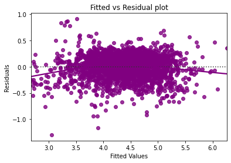

```python
# Plotting fitted values vs residuals

sns.residplot(
    data = df_pred, x = 'Fitted Values', y = 'Residuals', color = 'purple', lowess = True
)
plt.xlabel('Fitted Values')
plt.ylabel('Residuals')
plt.title('Fitted vs Residual plot')
plt.show()
```

- The scatter plot shows the distribution of residuals (errors) vs fitted values (predicted values).
- If a pattern existed in this plot, it is considered as a sign of non-linearity in the data and a pattern means that the model doesn't capture non-linear effects.
- **There is no pattern in the plot above. Hence, the assumptions of linearity and independence are satisfied.**

**Next the rest of the below assumptions will be checked on *olsmod4*.**

1. **Normality of error terms**
2. **No Heteroscedasticity**

### TEST FOR NORMALITY

**Why the test?**

- Error terms, or residuals, should be normally distributed. If the error terms are not normally distributed, confidence intervals of the coefficient estimates may become too wide or narrow. Once confidence interval becomes unstable, it leads to difficulty in estimating coefficients based on minimization of least squares. Non-normality suggests that there are a few unusual data points that must be studied closely to make a better model.

**How to check normality?**

- The shape of the histogram of residuals can give an initial idea about the normality.
- It can also be checked via a Q-Q plot of residuals. If the residuals follow a normal distribution, they will make a straight line plot, otherwise not.
- Other tests to check for normality includes the Shapiro-Wilk test.
  - Null hypothesis: Residuals are normally distributed
  - Alternate hypothesis: Residuals are not normally distributed

**How to fix if this assumption is not followed?**

- We can apply transformations like log, exponential, arcsinh, etc. as per our data.

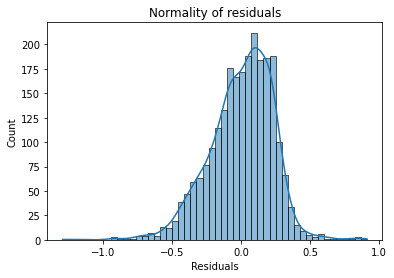

```python
# Plotting normality of residuals
sns.histplot(data = df_pred, x = 'Residuals', kde = True)
plt.title('Normality of residuals')
plt.show()
```

- The histogram of residuals does have a bell shape.
- Now going to check the Q-Q plot.

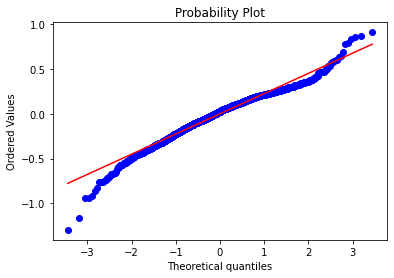

```python
import pylab
import scipy.stats as stats

stats.probplot(df_pred['Residuals'], dist = 'norm', plot = pylab)
plt.show()
```

- The residuals more or less follow a straight line except for the tails.
- Now going to check the results of the Shapiro-Wilk test.

```python
# Shapiro-Wilk test
stats.shapiro(df_pred['Residuals'])
```

```
ShapiroResult(statistic=0.9753472805023193, pvalue=5.145715784164498e-20)
```

- Since p-value < 0.05, the residuals are not normal as per the Shapiro-Wilk test.
- Strictly speaking, the residuals are not normal.
- However, as an approximation, this distribution will be accepted as close to being normal.
- **So, the assumption is satisfied.**

**Next the final assumption will be checked on *olsmod4*.**

1. **No Heteroscedasticity**

### TEST FOR HOMOSCEDASTICITY

- **Homoscedascity**: If the variance of the residuals is symmetrically distributed across the regression line, then the data is said to be homoscedastic.
- **Heteroscedascity**: If the variance is unequal for the residuals across the regression line, then the data is said to be heteroscedastic.

**Why the test?**

- The presence of non-constant variance in the error terms results in heteroscedasticity. Generally, non-constant variance arises in presence of outliers.

**How to check for homoscedasticity?**

- The residual vs fitted values plot can be looked at to check for homoscedasticity. In the case of heteroscedasticity, the residuals can form an arrow shape or any other non-symmetrical shape.
- The goldfeldquandt test can also be used. If we get a p-value > 0.05 we can say that the residuals are homoscedastic. Otherwise, they are heteroscedastic.
  - Null hypothesis: Residuals are homoscedastic
  - Alternate hypothesis: Residuals have heteroscedasticity

**How to fix if this assumption is not followed?**

- Heteroscedasticity can be fixed by adding other important features or making transformations.

```python
import statsmodels.stats.api as sms
from statsmodels.compat import lzip

name = ['F statistic', 'p-value']
test = sms.het_goldfeldquandt(df_pred['Residuals'], x_train4)
lzip(name, test)
```

```
[('F statistic', 1.0585450583553055), ('p-value', 0.1659452635133713)]
```

**Since p-value > 0.05, we can say that the residuals are homoscedastic. So, this assumption is satisfied.**

## Final Model Summary

**Now that we have checked all the assumptions of linear regression and they are satisfied, let's go ahead with prediction using olsmod4**

```python
# Predictions on the test set
pred = olsmod4.predict(x_test4)

df_pred_test = pd.DataFrame({'Actual': y_test, 'Predicted': pred})

# Converting values in df_pred to exponent to get the values back in Euros to compare predicted vs. actual
df_pred_test['Actual'] = np.exp(df_pred_test['Actual'])
df_pred_test['Predicted'] = np.exp(df_pred_test['Predicted'])

df_pred_test.sample(10, random_state = 1)
```

|  | Actual | Predicted |
| --- | --- | --- |
| 1995 | 97.23 | 80.219601 |
| 2341 | 41.29 | 52.960360 |
| 1913 | 37.31 | 42.996671 |
| 688 | 75.18 | 62.998992 |
| 650 | 93.03 | 165.211772 |
| 2291 | 71.76 | 82.395325 |
| 40 | 149.07 | 226.884667 |
| 1884 | 49.20 | 59.291716 |
| 2538 | 68.13 | 57.237828 |
| 45 | 218.12 | 197.378848 |

- The model has returned pretty good prediction results, and the actual and predicted values are comparable.
- A sample of the predicted and actual will be plotted on a bar graph. Not all data can be plotted since it would be too large to fit on a plot, so it will be a sample.

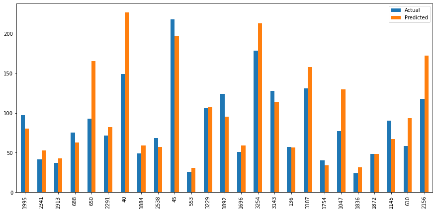

```python
# Plotting predicted vs. actual values
df_sample = df_pred_test.sample(25, random_state = 1)
df_sample.plot(kind ='bar', figsize=(15, 7))
plt.show()
```

```python
# checking model performance on train set (seen 70% data)
print('Training Performance\n')
olsmod4_train_perf = model_performance_regression(olsmod4, x_train4, y_train)
olsmod4_train_perf
```

```
Training Performance
```

|  | RMSE | MAE | R-squared | Adj. R-squared | MAPE |
| --- | --- | --- | --- | --- | --- |
| 0 | 0.228123 | 0.179047 | 0.841611 | 0.838605 | 4.254672 |

```python
# checking model performance on test set (seen 30% data)
print('Test Performance\n')
olsmod4_test_perf = model_performance_regression(olsmod4, x_test4, y_test)
olsmod4_test_perf
```

```
Test Performance
```

|  | RMSE | MAE | R-squared | Adj. R-squared | MAPE |
| --- | --- | --- | --- | --- | --- |
| 0 | 0.234786 | 0.181474 | 0.840997 | 0.833776 | 4.364939 |

- The model is able to explain ~84% of the variation in the data, which is very good.
- The train and test RMSE and MAE are low and comparable. So, our model is not suffering from overfitting.
- The MAPE on the test set suggests we can predict within ~4.4% of the used_price
- Model *olsmod4* is good for prediction as well as inference purposes.

```python
# Training performance comparison

models_train_comp_df = pd.concat(
    [olsmodel_train_perf.T, olsmod4_train_perf.T],
    axis = 1,
)

models_train_comp_df.columns = [
    'Linear Regression (all variables)',
    'Linear Regression (selected variables)',
]

print('Training performance comparison:')
models_train_comp_df
```

```
Training performance comparison:
```

|  | Linear Regression (all variables) | Linear Regression (selected variables) |
| --- | --- | --- |
| RMSE | 0.225349 | 0.228123 |
| MAE | 0.177475 | 0.179047 |
| R-squared | 0.845441 | 0.841611 |
| Adj. R-squared | 0.842241 | 0.838605 |
| MAPE | 4.221795 | 4.254672 |

```python
# Test performance comparison

models_test_comp_df = pd.concat(
    [olsmodel_test_perf.T, olsmod4_test_perf.T],
    axis = 1,
)

models_test_comp_df.columns = [
    'Linear Regression (all variables)',
    'Linear Regression (selected variables)',
]

print('Test performance comparison:')
models_test_comp_df
```

```
Test performance comparison:
```

|  | Linear Regression (all variables) | Linear Regression (selected variables) |
| --- | --- | --- |
| RMSE | 0.233151 | 0.234786 |
| MAE | 0.180884 | 0.181474 |
| R-squared | 0.843204 | 0.840997 |
| Adj. R-squared | 0.835419 | 0.833776 |
| MAPE | 4.359777 | 4.364939 |

- The performance of the two models is close to each other.

**Now going to recreate the final statsmodels model and print it's summary to gain insights.**

```python
olsmodel_final = sm.OLS(y_train, x_train4).fit()
print(olsmodel_final.summary())
```

```
                            OLS Regression Results
==============================================================================
Dep. Variable:         used_price_log   R-squared:                       0.842
Model:                            OLS   Adj. R-squared:                  0.839
Method:                 Least Squares   F-statistic:                     286.5
Date:                Fri, 04 Feb 2022   Prob (F-statistic):               0.00
Time:                        21:27:53   Log-Likelihood:                 142.43
No. Observations:                2417   AIC:                            -194.9
Df Residuals:                    2372   BIC:                             65.69
Df Model:                          44
Covariance Type:            nonrobust
=========================================================================================
                            coef    std err          t      P>|t|      [0.025      0.975]
-----------------------------------------------------------------------------------------
const                     1.2541      0.068     18.464      0.000       1.121       1.387
screen_size               0.0421      0.002     26.556      0.000       0.039       0.045
main_camera_mp            0.0178      0.001     12.641      0.000       0.015       0.021
selfie_camera_mp          0.0128      0.001     11.719      0.000       0.011       0.015
ram                       0.0207      0.005      4.172      0.000       0.011       0.030
age                      -0.0148      0.004     -4.097      0.000      -0.022      -0.008
new_price_log             0.4323      0.012     36.586      0.000       0.409       0.455
brand_name_Alcatel        0.0129      0.047      0.274      0.784      -0.080       0.105
brand_name_Apple         -0.0338      0.146     -0.232      0.816      -0.320       0.252
brand_name_Asus           0.0288      0.047      0.607      0.544      -0.064       0.122
brand_name_BlackBerry    -0.0345      0.070     -0.496      0.620      -0.171       0.102
brand_name_Celkon        -0.0143      0.064     -0.222      0.824      -0.141       0.112
brand_name_Coolpad        0.0442      0.072      0.612      0.541      -0.097       0.186
brand_name_Gionee         0.0439      0.057      0.769      0.442      -0.068       0.156
brand_name_Google        -0.0286      0.084     -0.342      0.733      -0.193       0.136
brand_name_HTC           -0.0047      0.048     -0.099      0.921      -0.098       0.089
brand_name_Honor          0.0157      0.049      0.322      0.747      -0.080       0.111
brand_name_Huawei        -0.0035      0.044     -0.079      0.937      -0.090       0.083
brand_name_Infinix        0.1198      0.092      1.303      0.193      -0.061       0.300
brand_name_Karbonn        0.0936      0.066      1.411      0.158      -0.036       0.224
brand_name_LG            -0.0122      0.045     -0.272      0.786      -0.100       0.076
brand_name_Lava           0.0304      0.062      0.492      0.623      -0.091       0.151
brand_name_Lenovo         0.0504      0.045      1.125      0.261      -0.037       0.138
brand_name_Meizu          0.0143      0.055      0.257      0.797      -0.095       0.123
brand_name_Micromax      -0.0234      0.047     -0.495      0.621      -0.116       0.069
brand_name_Microsoft      0.1159      0.087      1.324      0.186      -0.056       0.287
```

[output cut: 15 more lines]

```
os_Windows               -0.0153      0.045     -0.343      0.732      -0.103       0.072
os_iOS                    0.0044      0.145      0.030      0.976      -0.280       0.289
4g_yes                    0.0403      0.015      2.605      0.009       0.010       0.071
5g_yes                   -0.0316      0.031     -1.017      0.309      -0.093       0.029
==============================================================================
Omnibus:                      179.297   Durbin-Watson:                   1.910
Prob(Omnibus):                  0.000   Jarque-Bera (JB):              303.501
Skew:                          -0.550   Prob(JB):                     1.25e-66
Kurtosis:                       4.343   Cond. No.                     1.06e+03
==============================================================================

Notes:
[1] Standard Errors assume that the covariance matrix of the errors is correctly specified.
[2] The condition number is large, 1.06e+03. This might indicate that there are
strong multicollinearity or other numerical problems.
```

### Observations

- As screen_size, main_camera_mp, selfie_camera_mp, ram, and new_price_log go up, so would the used price of a device, which makes sense as screen_size implies a bigger device and more MP/RAM would mean better pictures/faster device performance. All of those features have positive coefficients.
- As age increases, used price goes down, which makes sense, as a device is used longer, it is subject to wear and tear. Age has a negative coefficient.
- Of all the brands, Infinx has the greatest positive coefficient for used price.

## Actionable Insights and Recommendations

- In the future, it might make sense to better categorize the devices by adding a column called device_type noting if the device is either a smartphone or tablet. With this granularity, ReCell can then explore the idea of creating two linear regression models, one for smartphones and one for tablets. That might lead to even better model accuracy than using one model to handle both model types. Having both smartphones and tablets having their own models might lead to more narrower/normal distributions and there might be less outliers.
- It also might make sense to add device name/model as that might be correlated in determining a used price.
- See if more data can be collected for training/testing purposes as that can help improve model performance.
- Another possibility might be to create linear regression models for each brand to see if that can optimize resale price for that brand. ReCell might want to consider doing this with their 3-5 top selling brands and see how the models' accuracy compares to the accuracy of olsmod4.
- This model should be retrained because there might be new features to account for in devices or features that were missed out from before (e.g. OLED display, 4K video recording, Bluetooth, Wireless charging, etc.) that can influence pricing.